# Introduction to R

Back to schedule

```r
a_thing <- 4
another_thing <- 1
another_Thing <- 7

both_things <- a_thing + another_thing
```

Then we created a tiny data set.

```r
a_data_thing <- data.frame(x = 2, y = 8)

a_data_thing$x
```

```
## [1] 2
```

```r
#How would we print the variable y? Type your answer below on line 17.
```

Write notes for yourself in the white space. Maybe explain to your future self what dollar signs do.

Enough playing around, let’s load some data!

```r
riggsi <- read.csv("riggsi.csv")
```

Next, you want to look at your data.

```r
head(riggsi)
```

```
##   Dyad Partner Age Gender Abuse Sat     Avoid   Anxiety Rel_Length
## 1    1       1  21     -1     5  48 0.2777778 2.2777778   1.083333
## 2    1       2  20      1     5  51 0.0000000 3.8888889   1.083333
## 3    2       1  22      1    15  43 1.4444444 3.4444444   3.416667
## 4    2       2  21     -1    16  47 0.3333333 0.8888889   3.416667
## 5    3       1  32     -1     7  52 0.3333333 1.5555556   1.666667
## 6    3       2  21      1    13  38 0.8333333 5.6111111   1.666667
##   Genderstring
## 1          Man
## 2        Woman
## 3        Woman
## 4          Man
## 5          Man
## 6        Woman
```

```r
str(riggsi)
```

```
## 'data.frame':    310 obs. of  10 variables:
##  $ Dyad        : int  1 1 2 2 3 3 5 5 6 6 ...
##  $ Partner     : int  1 2 1 2 1 2 1 2 1 2 ...
##  $ Age         : int  21 20 22 21 32 21 18 19 22 21 ...
##  $ Gender      : int  -1 1 1 -1 -1 1 1 -1 -1 1 ...
##  $ Abuse       : num  5 5 15 16 7 13 5 5 5 5 ...
##  $ Sat         : int  48 51 43 47 52 38 50 45 50 57 ...
##  $ Avoid       : num  0.278 0 1.444 0.333 0.333 ...
##  $ Anxiety     : num  2.278 3.889 3.444 0.889 1.556 ...
##  $ Rel_Length  : num  1.08 1.08 3.42 3.42 1.67 ...
##  $ Genderstring: Factor w/ 2 levels "Man","Woman": 1 2 2 1 1 2 2 1 1 2 ...
```

```r
names(riggsi)
```

```
##  [1] "Dyad"         "Partner"      "Age"          "Gender"
##  [5] "Abuse"        "Sat"          "Avoid"        "Anxiety"
##  [9] "Rel_Length"   "Genderstring"
```

There is also documentation about functions.

```r
?head
```

You probably also want descriptive statistics.

```r
summary(riggsi)
```

```
##       Dyad           Partner         Age           Gender
##  Min.   :  1.00   Min.   :1.0   Min.   :17.0   Min.   :-1
##  1st Qu.: 43.25   1st Qu.:1.0   1st Qu.:19.0   1st Qu.:-1
##  Median : 88.00   Median :1.5   Median :21.0   Median : 0
##  Mean   : 87.69   Mean   :1.5   Mean   :21.9   Mean   : 0
##  3rd Qu.:131.75   3rd Qu.:2.0   3rd Qu.:23.0   3rd Qu.: 1
##  Max.   :174.00   Max.   :2.0   Max.   :46.0   Max.   : 1
##      Abuse             Sat            Avoid           Anxiety
##  Min.   : 4.404   Min.   :20.00   Min.   :0.0000   Min.   :0.000
##  1st Qu.: 5.000   1st Qu.:41.00   1st Qu.:0.5556   1st Qu.:1.847
##  Median : 7.000   Median :46.00   Median :1.2222   Median :2.778
##  Mean   : 8.888   Mean   :44.82   Mean   :1.4591   Mean   :2.780
##  3rd Qu.:11.000   3rd Qu.:50.00   3rd Qu.:2.1111   3rd Qu.:3.611
##  Max.   :25.000   Max.   :61.00   Max.   :5.7222   Max.   :5.667
##    Rel_Length     Genderstring
##  Min.   :0.4167   Man  :155
##  1st Qu.:0.8333   Woman:155
##  Median :1.4583
##  Mean   :1.7386
##  3rd Qu.:2.4896
##  Max.   :5.0000
```

We can also select pieces of a data frame. That first number is the row, the second is the column.

```r
riggsi[2, 6]
```

```
## [1] 51
```

```r
#You try it! Find a numder you want to pull from the dataset.
#riggsi[ ?, ?]
```

If it is instead a single variable, you can also select a piece.

```r
riggsi$Sat[2]
```

```
## [1] 51
```

# More Intro to R

More descriptive stats and frequencies with sample proportions. We’ll use the package `mosaic`. To download a cheat sheet for `mosaic` [click here](http://github.com/rstudio/cheatsheets/raw/master/mosaic.pdf).

```r
library(mosaic)
```

```r
favstats(~Sat, data = riggsi)
```

```
##  min Q1 median Q3 max     mean      sd   n missing
##   20 41     46 50  61 44.81613 7.30707 310       0
```

```r
tally(~Gender, data = riggsi, format = "proportion")
```

```
## Gender
##  -1   1
## 0.5 0.5
```

Descriptives split by gender.

```r
favstats(Sat ~ Gender, data = riggsi)
```

```
##   Gender min Q1 median Q3 max     mean       sd   n missing
## 1     -1  24 40     46 50  61 44.85806 7.171769 155       0
## 2      1  20 41     46 50  60 44.77419 7.462937 155       0
```

## Data Manipulation

We’ll use the package `dplyr`. For the cheatsheet [click here](http://github.com/rstudio/cheatsheets/raw/master/data-transformation.pdf).

First, let’s filter cases.

```r
library(dplyr)
```

We can make a dataset of men only.

```r
menOnly <- filter(riggsi, Gender == -1)
```

We can save this new data set in our files as a csv.

```r
write.csv(menOnly, "men.csv")
```

It’s in the same folder where this .Rmd file is saved! You can be more specific with the file path if you choose.

How about only the men of drinking age.

```r
legal_drinkers <- menOnly %>% filter(Age > 20)
```

Note the use of the pipe, `%>%`, above. The two statements below are equivalent.

```r
legal_drinkers <- filter(menOnly, Age > 20)

legal_drinkers <- menOnly %>% filter(Age > 20)
```

Adding new variables.

```r
menOnly <- menOnly %>%
  mutate(legal = Age > 20)

favstats(Age ~ legal, data = menOnly)
```

```
##   legal min Q1 median Q3 max     mean        sd   n missing
## 1 FALSE  18 19     19 20  20 19.12963 0.7781521  54       0
## 2  TRUE  21 22     23 26  43 24.61386 4.4810050 101       0
```

Alternative method for descriptive statistic—the `dplyr` way.

```r
riggsi %>%
  summarize(mean = mean(Sat),
            sd = sd(Sat),
            min = min(Sat))
```

```
##       mean      sd min
## 1 44.81613 7.30707  20
```

We can split the file and view results grouped by some variable.

```r
riggsi %>%
  group_by(Gender) %>%
  summarize(mean = mean(Sat),
            sd = sd(Sat),
            min = min(Sat))
```

```
## # A tibble: 2 x 4
##   Gender  mean    sd   min
##    <int> <dbl> <dbl> <dbl>
## 1     -1  44.9  7.17   24.
## 2      1  44.8  7.46   20.
```

Save a smaller subset of variables.

```r
small <- riggsi %>%
  select(Dyad, Partner, Sat, Avoid)
```

## Visualizing Data

Let’s make a histogram. We’ll use the package `ggplot2` to make our visualizations. To download a cheatsheet for `ggplot2` [click here](http://github.com/rstudio/cheatsheets/raw/master/data-visualization-2.1.pdf)

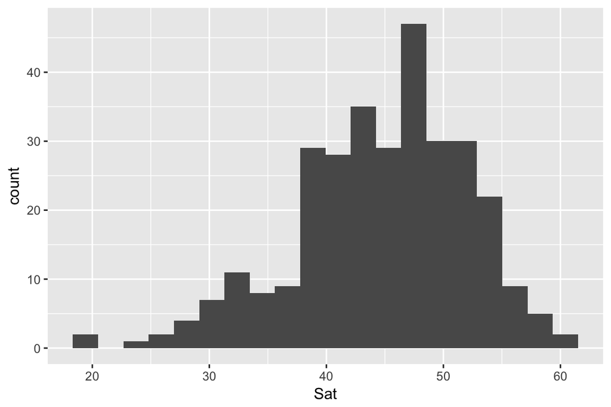

```r
qplot(x = Sat, data = riggsi, bins = 20)
```

Scatterplot. `qplot`, which stands for quick plot, guesses which kind of figure you want.

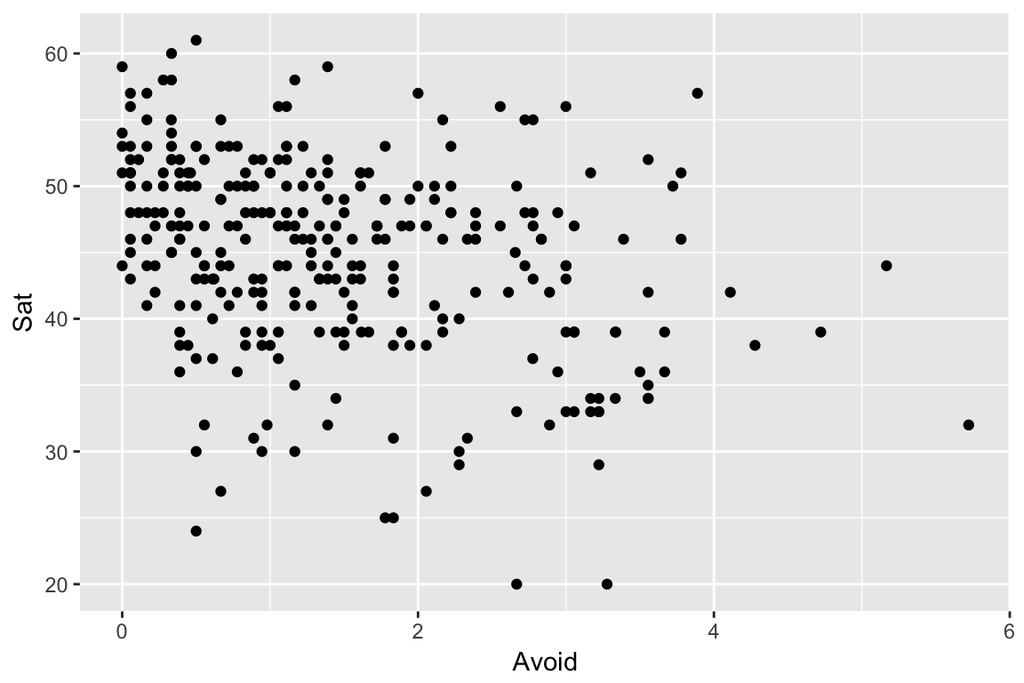

```r
qplot(x = Avoid, y = Sat, data = riggsi)
```

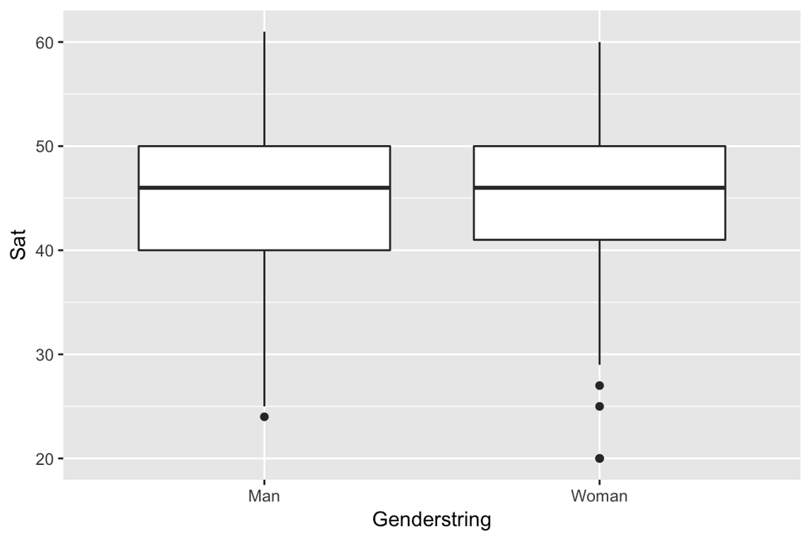

```r
qplot(y = Sat, x = Genderstring, data = riggsi, geom = "boxplot")
```

We can add a regression line.

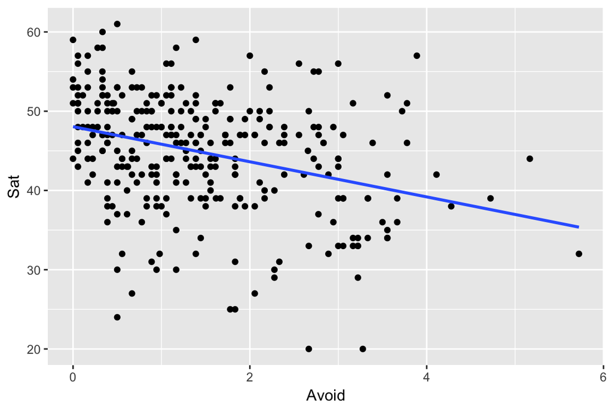

```r
qplot(x = Avoid, y = Sat, data = riggsi) + geom_smooth(method = "lm", se = 0)
```

We can also split by gender. Note that for more complex models we need to move away from using the `qplot` function in favor of the heavy duty `ggplot` function.

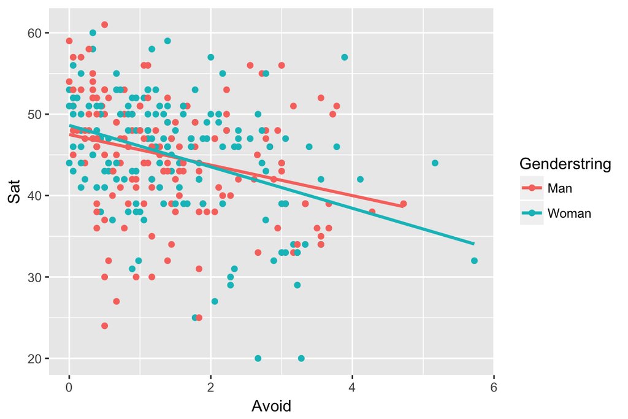

```r
ggplot(riggsi, aes(x = Avoid, y = Sat, group = Genderstring, color = Genderstring)) +
         geom_point() +
         geom_smooth(method = "lm", se = 0)
```

## Statistical Modeling and Inference in R

Independent samples t-test, making use of the `t.test()` function in the `mosaic` package.

```r
t.test(Sat ~ legal, data = menOnly, var.equal = TRUE)
```

```
## Sat ~ legal
```

```
##
##  Two Sample t-test
##
## data:  Sat by legal
## t = -0.12502, df = 153, p-value = 0.9007
## alternative hypothesis: true difference in means is not equal to 0
## 95 percent confidence interval:
##  -2.547837  2.244573
## sample estimates:
## mean in group FALSE  mean in group TRUE
##            44.75926            44.91089
```

Paired samples t-test.

```r
t.test(~(Sat-Avoid), data = menOnly)
```

```
## ~(Sat - Avoid)
```

```
##
##  One Sample t-test
##
## data:  Sat
## t = 71.688, df = 154, p-value < 2.2e-16
## alternative hypothesis: true mean is not equal to 0
## 95 percent confidence interval:
##  42.25412 44.64887
## sample estimates:
## mean of x
##  43.45149
```

Linear regression.

```r
mod <- lm(Sat ~ Avoid + legal, data = menOnly)

summary(mod)
```

```
##
## Call:
## lm(formula = Sat ~ Avoid + legal, data = menOnly)
##
## Residuals:
##     Min      1Q  Median      3Q     Max
## -22.480  -3.620   0.316   4.650  14.401
##
## Coefficients:
##             Estimate Std. Error t value Pr(>|t|)
## (Intercept)  47.4177     1.1953  39.671  < 2e-16 ***
## Avoid        -1.8745     0.5183  -3.617 0.000405 ***
## legalTRUE     0.1182     1.1677   0.101 0.919476
## ---
## Signif. codes:  0 '***' 0.001 '**' 0.01 '*' 0.05 '.' 0.1 ' ' 1
##
## Residual standard error: 6.927 on 152 degrees of freedom
## Multiple R-squared:  0.07934,    Adjusted R-squared:  0.06722
## F-statistic: 6.549 on 2 and 152 DF,  p-value: 0.001869
```

Regression diagnostics.

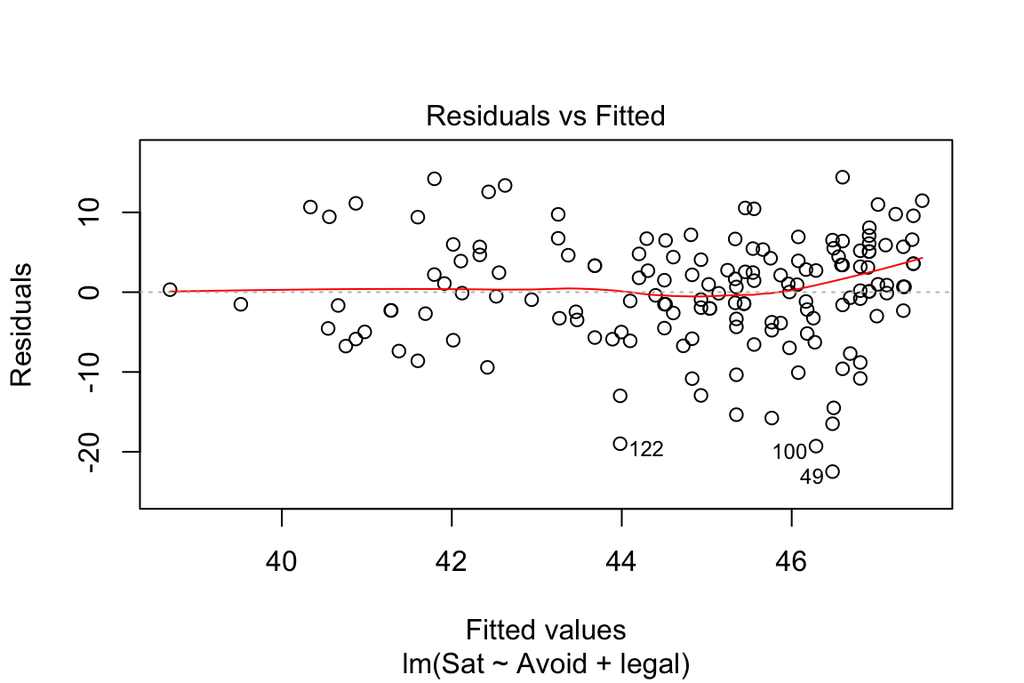

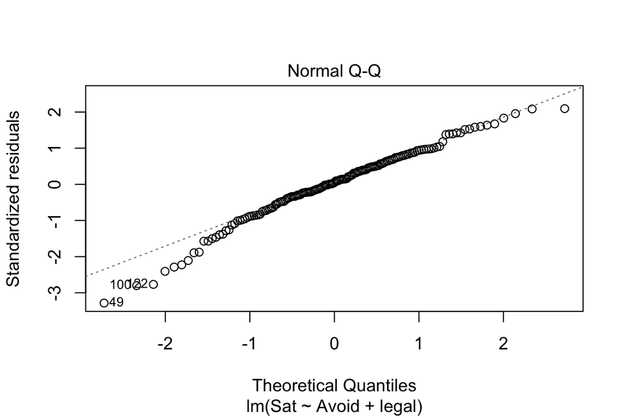

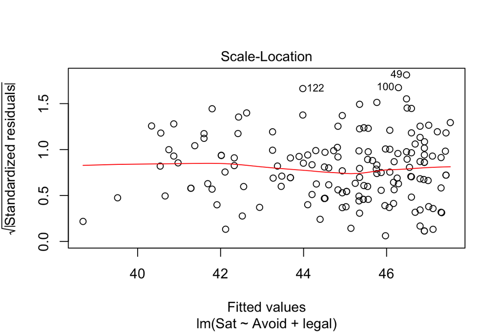

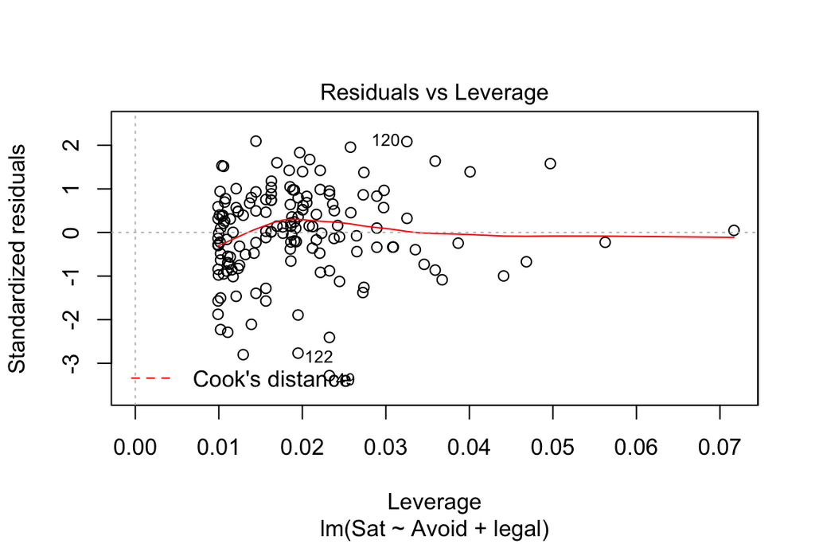

```r
plot(mod)
```

Back to schedule